```python
import pandas as pd
import matplotlib.pyplot as plt
import numpy as np
import seaborn as sb
```

```python
df=pd.read_excel(r"C:\Users\ZAX PHOTOGRAPHY\Desktop\Gabriel photos\LITA Capstone Dataset.xlsx")
df
```

|  | OrderID | Customer Id | Product | Region | OrderDate | Quantity | UnitPrice |
| --- | --- | --- | --- | --- | --- | --- | --- |
| 0 | 1001 | Cus1278 | Shirt | North | 2023-01-31 | 5 | 20 |
| 1 | 1002 | Cus1022 | Shoes | South | 2023-02-28 | 10 | 50 |
| 2 | 1003 | Cus1064 | Hat | East | 2023-03-31 | 7 | 15 |
| 3 | 1004 | Cus1327 | Socks | West | 2023-04-30 | 3 | 5 |
| 4 | 1005 | Cus1309 | Jacket | North | 2023-05-31 | 2 | 60 |
| ... | ... | ... | ... | ... | ... | ... | ... |
| 49995 | 1016 | Cus1405 | Socks | West | 2024-04-30 | 4 | 20 |
| 49996 | 1017 | Cus1125 | Jacket | North | 2024-05-31 | 3 | 30 |
| 49997 | 1018 | Cus1022 | Gloves | South | 2024-06-30 | 12 | 25 |
| 49998 | 1019 | Cus1407 | Shoes | East | 2024-07-31 | 5 | 15 |
| 49999 | 1020 | Cus1217 | Hat | West | 2024-08-31 | 7 | 50 |

50000 rows × 7 columns

The Orders table is a relational database table containing seven columns: Order ID (unique identifier), Customer ID (foreign key), Product, Region, Order Date, Quantity, and Unit Price, designed to store and manage customer order data.

## Filteration

```python
df[df['Quantity']>3]
```

|  | OrderID | Customer Id | Product | Region | OrderDate | Quantity | UnitPrice |
| --- | --- | --- | --- | --- | --- | --- | --- |
| 0 | 1001 | Cus1278 | Shirt | North | 2023-01-31 | 5 | 20 |
| 1 | 1002 | Cus1022 | Shoes | South | 2023-02-28 | 10 | 50 |
| 2 | 1003 | Cus1064 | Hat | East | 2023-03-31 | 7 | 15 |
| 5 | 1006 | Cus1141 | Gloves | South | 2023-06-30 | 8 | 25 |
| 6 | 1007 | Cus1199 | Shirt | East | 2023-07-31 | 12 | 40 |
| ... | ... | ... | ... | ... | ... | ... | ... |
| 49994 | 1015 | Cus1251 | Hat | East | 2024-03-31 | 11 | 10 |
| 49995 | 1016 | Cus1405 | Socks | West | 2024-04-30 | 4 | 20 |
| 49997 | 1018 | Cus1022 | Gloves | South | 2024-06-30 | 12 | 25 |
| 49998 | 1019 | Cus1407 | Shoes | East | 2024-07-31 | 5 | 15 |
| 49999 | 1020 | Cus1217 | Hat | West | 2024-08-31 | 7 | 50 |

42500 rows × 7 columns

This table displays high-volume orders, listing Order ID, Customer ID, Product, Region, Order Date, Quantity, and Unit Price for orders with a quantity exceeding 3 units.

## Pivot Table

```python
pivot1= pd.pivot_table(df, index='Region',values ='Quantity')
pivot1
```

| Region | Quantity |
| --- | --- |
| East | 8.2 |
| North | 5.0 |
| South | 9.8 |
| West | 4.6 |

```python
pivot2= pd.pivot_table(df, index='Region',columns='Product', values ='Quantity', aggfunc='count', fill_value=0)
pivot2
```

| Product Region | Gloves | Hat | Jacket | Shirt | Shoes | Socks |
| --- | --- | --- | --- | --- | --- | --- |
| East | 0 | 5000 | 2500 | 2500 | 2500 | 0 |
| North | 0 | 2500 | 5000 | 5000 | 0 | 0 |
| South | 5000 | 0 | 0 | 0 | 5000 | 2500 |
| West | 2500 | 2500 | 0 | 0 | 2500 | 5000 |

The pivot table above displays the count of orders for each product by region, showing the number of orders for each product in each geographic area, with zero-filled gaps for non-existent combinations.

```python
pivot3= pd.pivot_table(df, index='Product',columns='Region', values='UnitPrice', aggfunc= 'count', fill_value=0)
pivot3
```

| Region Product | East | North | South | West |
| --- | --- | --- | --- | --- |
| Gloves | 0 | 0 | 5000 | 2500 |
| Hat | 5000 | 2500 | 0 | 2500 |
| Jacket | 2500 | 5000 | 0 | 0 |
| Shirt | 2500 | 5000 | 0 | 0 |
| Shoes | 2500 | 0 | 5000 | 2500 |
| Socks | 0 | 0 | 2500 | 5000 |

The pivot table summarizes the count of unit prices for each product across different regions, with missing values replaced by zero, allowing for a clear comparison of product availability by region.

```python
pivot4= pd.pivot_table(df, index='Product',columns='Region', values='UnitPrice', aggfunc= ['count', 'sum', 'mean'], fill_value=0)
pivot4
```

| Region Product | count East | count North | count South | count West | sum East | sum North | sum South | sum West | mean East | mean North | mean South | mean West |
| --- | --- | --- | --- | --- | --- | --- | --- | --- | --- | --- | --- | --- |
| Gloves | 0 | 0 | 5000 | 2500 | 0 | 0 | 125000 | 50000 | 0.0 | 0.0 | 25.0 | 20.0 |
| Hat | 5000 | 2500 | 0 | 2500 | 62500 | 25000 | 0 | 125000 | 12.5 | 10.0 | 0.0 | 50.0 |
| Jacket | 2500 | 5000 | 0 | 0 | 87500 | 225000 | 0 | 0 | 35.0 | 45.0 | 0.0 | 0.0 |
| Shirt | 2500 | 5000 | 0 | 0 | 100000 | 175000 | 0 | 0 | 40.0 | 35.0 | 0.0 | 0.0 |
| Shoes | 2500 | 0 | 5000 | 2500 | 37500 | 0 | 275000 | 37500 | 15.0 | 0.0 | 55.0 | 15.0 |
| Socks | 0 | 0 | 2500 | 5000 | 0 | 0 | 75000 | 62500 | 0.0 | 0.0 | 30.0 | 12.5 |

The pivot table displays the count, sum, and mean of unit prices for each product organized by region, with any missing values filled with zero, providing a comprehensive overview of product performance across regions.

```python
pivot5= pd.pivot_table(df, index='Region',values ='Quantity',aggfunc='count')
pivot5
```

| Region | Quantity |
| --- | --- |
| East | 12500 |
| North | 12500 |
| South | 12500 |
| West | 12500 |

```python
pivot6= pd.pivot_table(df, index='Product',columns='Region', values=['UnitPrice', 'Quantity'], aggfunc= ['count', 'sum', 'mean'], fill_value=0)
pivot6
```

| Region Product | count Quantity East | count Quantity North | count Quantity South | count Quantity West | count UnitPrice East | count UnitPrice North | count UnitPrice South | count UnitPrice West | sum Quantity East | sum Quantity North | sum ... | sum UnitPrice South | sum UnitPrice West | mean Quantity East | mean Quantity North | mean Quantity South | mean Quantity West | mean UnitPrice East | mean UnitPrice North | mean UnitPrice South | mean UnitPrice West |
| --- | --- | --- | --- | --- | --- | --- | --- | --- | --- | --- | --- | --- | --- | --- | --- | --- | --- | --- | --- | --- | --- |
| Gloves | 0 | 0 | 5000 | 2500 | 0 | 0 | 5000 | 2500 | 0 | 0 | ... | 125000 | 50000 | 0.0 | 0.0 | 10.0 | 5.0 | 0.0 | 0.0 | 25.0 | 20.0 |
| Hat | 5000 | 2500 | 0 | 2500 | 5000 | 2500 | 0 | 2500 | 45000 | 17500 | ... | 0 | 125000 | 9.0 | 7.0 | 0.0 | 7.0 | 12.5 | 10.0 | 0.0 | 50.0 |
| Jacket | 2500 | 5000 | 0 | 0 | 2500 | 5000 | 0 | 0 | 15000 | 12500 | ... | 0 | 0 | 6.0 | 2.5 | 0.0 | 0.0 | 35.0 | 45.0 | 0.0 | 0.0 |
| Shirt | 2500 | 5000 | 0 | 0 | 2500 | 5000 | 0 | 0 | 30000 | 32500 | ... | 0 | 0 | 12.0 | 6.5 | 0.0 | 0.0 | 40.0 | 35.0 | 0.0 | 0.0 |
| Shoes | 2500 | 0 | 5000 | 2500 | 2500 | 0 | 5000 | 2500 | 12500 | 0 | ... | 275000 | 37500 | 5.0 | 0.0 | 10.0 | 4.0 | 15.0 | 0.0 | 55.0 | 15.0 |
| Socks | 0 | 0 | 2500 | 5000 | 0 | 0 | 2500 | 5000 | 0 | 0 | ... | 75000 | 62500 | 0.0 | 0.0 | 9.0 | 3.5 | 0.0 | 0.0 | 30.0 | 12.5 |

6 rows × 24 columns

This pivot table organizes data with 'Product' as the index and 'Region' as the columns, displaying the count, sum, and mean of 'UnitPrice' and 'Quantity' values, replacing any missing entries with zero.

```python
pivot7= pd.pivot_table(df, index='Customer Id',columns=['Region', 'Product'], values='UnitPrice', aggfunc= ['count', 'sum', 'mean'], fill_value=0)
pivot7
```

| Region Product Customer Id | count East Hat | count East Jacket | count East Shirt | count East Shoes | count North Hat | count North Jacket | count North Shirt | count South Gloves | count South Shoes | count South Socks | ... | mean North Hat | mean North Jacket | mean North Shirt | mean South Gloves | mean South Shoes | mean South Socks | mean West Gloves | mean West Hat | mean West Shoes | mean West Socks |
| --- | --- | --- | --- | --- | --- | --- | --- | --- | --- | --- | --- | --- | --- | --- | --- | --- | --- | --- | --- | --- | --- |
| Cus1001 | 11 | 5 | 7 | 3 | 3 | 8 | 9 | 5 | 9 | 2 | ... | 10.0 | 48.750000 | 33.333333 | 25.0 | 54.444444 | 30.0 | 20.0 | 50.0 | 15.0 | 12.500000 |
| Cus1002 | 8 | 6 | 1 | 5 | 6 | 14 | 6 | 11 | 7 | 4 | ... | 10.0 | 38.571429 | 45.000000 | 25.0 | 55.714286 | 30.0 | 20.0 | 50.0 | 15.0 | 12.894737 |
| Cus1003 | 13 | 3 | 4 | 3 | 7 | 5 | 14 | 11 | 11 | 4 | ... | 10.0 | 48.000000 | 35.000000 | 25.0 | 51.818182 | 30.0 | 20.0 | 50.0 | 15.0 | 10.454545 |
| Cus1004 | 8 | 6 | 9 | 2 | 7 | 6 | 10 | 9 | 12 | 4 | ... | 10.0 | 40.000000 | 32.000000 | 25.0 | 55.833333 | 30.0 | 20.0 | 50.0 | 15.0 | 12.500000 |
| Cus1005 | 3 | 4 | 2 | 6 | 3 | 12 | 11 | 4 | 10 | 12 | ... | 10.0 | 52.500000 | 39.090909 | 25.0 | 54.000000 | 30.0 | 20.0 | 50.0 | 15.0 | 17.000000 |
| ... | ... | ... | ... | ... | ... | ... | ... | ... | ... | ... | ... | ... | ... | ... | ... | ... | ... | ... | ... | ... | ... |
| Cus1496 | 6 | 5 | 6 | 1 | 5 | 10 | 8 | 5 | 9 | 6 | ... | 10.0 | 45.000000 | 38.750000 | 25.0 | 53.333333 | 30.0 | 20.0 | 50.0 | 15.0 | 10.625000 |
| Cus1497 | 4 | 3 | 10 | 6 | 3 | 5 | 9 | 10 | 8 | 10 | ... | 10.0 | 48.000000 | 40.000000 | 25.0 | 57.500000 | 30.0 | 20.0 | 50.0 | 15.0 | 14.375000 |
| Cus1498 | 7 | 7 | 6 | 3 | 8 | 17 | 10 | 10 | 11 | 4 | ... | 10.0 | 51.176471 | 44.000000 | 25.0 | 55.454545 | 30.0 | 20.0 | 50.0 | 15.0 | 6.500000 |
| Cus1499 | 10 | 3 | 8 | 3 | 4 | 11 | 12 | 13 | 12 | 7 | ... | 10.0 | 38.181818 | 32.500000 | 25.0 | 54.166667 | 30.0 | 20.0 | 50.0 | 15.0 | 10.625000 |
| Cus1500 | 10 | 3 | 10 | 6 | 1 | 6 | 11 | 12 | 12 | 8 | ... | 10.0 | 45.000000 | 33.636364 | 25.0 | 55.000000 | 30.0 | 20.0 | 50.0 | 15.0 | 7.307692 |

500 rows × 42 columns

This pivot table organizes data by 'Customer Id' as the index, with 'Region' and 'Product' as columns, displaying the count, sum, and mean of 'UnitPrice' values, while replacing any missing data with zero

# visualisation

## Scatter plot

```python
x=pivot1
y=pivot5
```

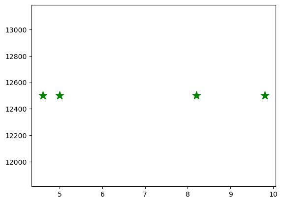

```python
plt.scatter(x, y, c= "g", s=150,  marker="*")
```

```python
H_data= np.random.random(50) * 100
L_data= np.random.random(50) * 100
```

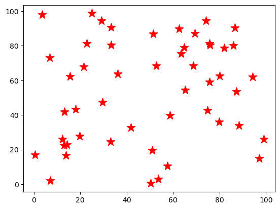

```python
plt.scatter(H_data, L_data, c= "red", s=150, marker="*")
```

The scatter plot displays 50 random data points, with `H_data` on the x-axis and `L_data` on the y-axis, showcasing a uniform distribution of values between 0 and 100, potentially indicating a lack of correlation between the two datasets.

## Line plot

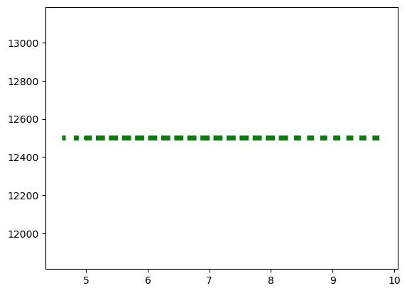

```python
plt.plot(pivot1, pivot5, c="green", lw=5, linestyle=":")
```

## Bar Chart

```python
x=['car', 'house', 'aeroplane', 'land', 'school']
y=[20, 30, 40, 50, 60]
```

[output not shown]

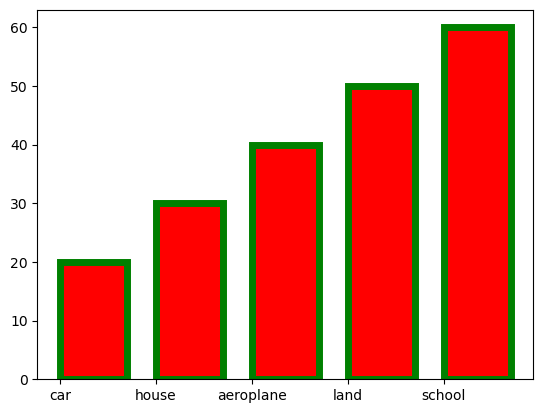

```python
plt.bar(x,y, color="red", align="edge", width=0.7, edgecolor="green", lw=5)
```

The bar chart displays five categories—car, house, aeroplane, land, and school—alongside their corresponding values of 20, 30, 40, 50, and 60, visually highlighting a steady increase in value from car to school.

## Histogram

```python
ages= np.random.normal(20, 1.5, 1000)
```

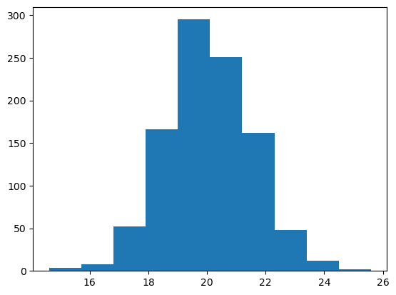

```python
plt.hist(ages)
```

The histogram displays a bell-shaped distribution of ages centered around 20 years, with most values clustered between 17 and 23 years, reflecting the normal distribution generated by the specified mean and standard deviation.

## pie chart

[output not shown]

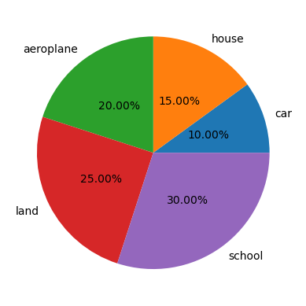

```python
plt.pie(y, labels=x, autopct="%.2f%%", pctdistance=0.5)
```

The pie chart displays the distribution of five categories—car, house, airplane, land, and school—with corresponding values of 20, 30, 40, 50, and 60, respectively, visually illustrating the varying proportions of each category.

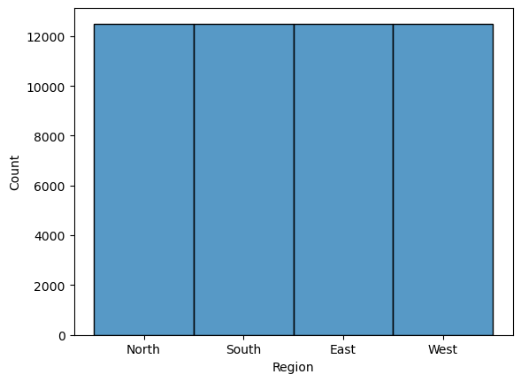

```python
sb.histplot(df['Region'])
```

A histogram with the x-axis labeled 'Region' and the y-axis labeled 'Count' visually represents the distribution of counts across different geographical or categorical regions, illustrating how many observations fall within each specified area.